# Homework 3 Solutions

Alexandra Chronopoulou

### Part I: Practice Questions

1. **Grocery Retailer**  
   A large national grocery retailer tracks productivity and cost of its facilities closely. The data in the `grocery.txt` file were obtained from a single distribution center for a one year period. Each data point for each variable represents one week of activity. The variables included are the `number of cases shipped` ($X_1$), the indirect costs of the `total labor hours` as a percentage ($X_2$), a qualitative predictor called `holiday` that is called in one of the week has a holy day and zero otherwise ($X_3$), and the `total labor hours` ($Y$).
   1. Fit a regression model to the data for the three predictor variables. State the estimated regression function.

      ```r
      library(ggcorrplot)
      library(ggplot2)

      grocery = read.table("grocery.txt", header=FALSE)
      head(grocery)
      ```

      ```
      ##     V1     V2   V3 V4
      ## 1 4264 305657 7.17  0
      ## 2 4496 328476 6.20  0
      ## 3 4317 317164 4.61  0
      ## 4 4292 366745 7.02  0
      ## 5 4945 265518 8.61  1
      ## 6 4325 301995 6.88  0
      ```

      ```r
      grocery.reg = lm(V1~., data=grocery)
      summary(grocery.reg)
      ```

      ```
      ##
      ## Call:
      ## lm(formula = V1 ~ ., data = grocery)
      ##
      ## Residuals:
      ##     Min      1Q  Median      3Q     Max
      ## -264.05 -110.73  -22.52   79.29  295.75
      ##
      ## Coefficients:
      ##               Estimate Std. Error t value Pr(>|t|)
      ## (Intercept)  4.150e+03  1.956e+02  21.220  < 2e-16 ***
      ## V2           7.871e-04  3.646e-04   2.159   0.0359 *
      ## V3          -1.317e+01  2.309e+01  -0.570   0.5712
      ## V4           6.236e+02  6.264e+01   9.954 2.94e-13 ***
      ## ---
      ## Signif. codes:  0 '***' 0.001 '**' 0.01 '*' 0.05 '.' 0.1 ' ' 1
      ##
      ## Residual standard error: 143.3 on 48 degrees of freedom
      ## Multiple R-squared:  0.6883, Adjusted R-squared:  0.6689
      ## F-statistic: 35.34 on 3 and 48 DF,  p-value: 3.316e-12
      ```

      ```r
      summary(grocery.reg)$r.squared
      ```

      ```
      ## [1] 0.6883342
      ```

   3. Test whether there is a regression relation, using $\alpha=0.05$. State the alternatives, decision rule, and conclusion. What does your test imply about $\beta_1$, $\beta_2$ and $\beta_2$?

      $$\begin{cases}
      &H_0: \beta_1=\beta_2=\beta_3=0\\
      &H_{\alpha}: \beta_j\neq 0, \text{ for some } j
      \end{cases}$$

      ```r
      grocery <- read.table("grocery.txt", header=FALSE)
      names(grocery) <- c("labor", "cases", "cost", "holiday")
      grocery.full = lm(labor~., data=grocery)
      summary(grocery.full)
      ```

      ```
      ##
      ## Call:
      ## lm(formula = labor ~ ., data = grocery)
      ##
      ## Residuals:
      ##     Min      1Q  Median      3Q     Max
      ## -264.05 -110.73  -22.52   79.29  295.75
      ##
      ## Coefficients:
      ##               Estimate Std. Error t value Pr(>|t|)
      ## (Intercept)  4.150e+03  1.956e+02  21.220  < 2e-16 ***
      ## cases        7.871e-04  3.646e-04   2.159   0.0359 *
      ## cost        -1.317e+01  2.309e+01  -0.570   0.5712
      ## holiday      6.236e+02  6.264e+01   9.954 2.94e-13 ***
      ## ---
      ## Signif. codes:  0 '***' 0.001 '**' 0.01 '*' 0.05 '.' 0.1 ' ' 1
      ##
      ## Residual standard error: 143.3 on 48 degrees of freedom
      ## Multiple R-squared:  0.6883, Adjusted R-squared:  0.6689
      ## F-statistic: 35.34 on 3 and 48 DF,  p-value: 3.316e-12
      ```

      Since the $p$-value $<<$ 0.05, we reject the null and conclude that the full model is adequate.
   4. Test whether $X_3$ can be dropped from the regression model given that $X_1$, $X_2$ are retained. Use level of significance 0.025. State the alternatives, decision rule and conclusion.
      $$\begin{cases}
      &H_0: \beta_3=0\\
      &H_{\alpha}: \beta_3\neq 0
      \end{cases}$$

      ```r
       grocery.reducedX3 = lm(labor~cases+cost, data=grocery)
      summary(grocery.reducedX3)
      ```

      ```
      ##
      ## Call:
      ## lm(formula = labor ~ cases + cost, data = grocery)
      ##
      ## Residuals:
      ##     Min      1Q  Median      3Q     Max
      ## -376.21 -173.77  -49.36  123.73  601.11
      ##
      ## Coefficients:
      ##              Estimate Std. Error t value Pr(>|t|)
      ## (Intercept) 3.995e+03  3.378e+02  11.829 5.72e-16 ***
      ## cases       9.192e-04  6.312e-04   1.456    0.152
      ## cost        1.212e+01  3.977e+01   0.305    0.762
      ## ---
      ## Signif. codes:  0 '***' 0.001 '**' 0.01 '*' 0.05 '.' 0.1 ' ' 1
      ##
      ## Residual standard error: 248.3 on 49 degrees of freedom
      ## Multiple R-squared:  0.04494,    Adjusted R-squared:  0.005953
      ## F-statistic: 1.153 on 2 and 49 DF,  p-value: 0.3242
      ```

      ```r
      anova(grocery.full, grocery.reducedX3)
      ```

      ```
      ## Analysis of Variance Table
      ##
      ## Model 1: labor ~ cases + cost + holiday
      ## Model 2: labor ~ cases + cost
      ##   Res.Df     RSS Df Sum of Sq      F    Pr(>F)
      ## 1     48  985530
      ## 2     49 3020044 -1  -2034514 99.091 2.941e-13 ***
      ## ---
      ## Signif. codes:  0 '***' 0.001 '**' 0.01 '*' 0.05 '.' 0.1 ' ' 1
      ```

      Since the $p$-value 2.941e-13 $<<$ 0.025, we reject the null that the reduced model is correct.
   5. Test whether both $X_2$ and $X_3$ can be dropped from the regression model, given that $X_1$ is retained. Use level of significance 0.025. State the alternatives, decision rule and conclusion.

      ```r
       grocery.reducedX2X3 = lm(labor~cases, data=grocery)
      summary(grocery.reducedX2X3)
      ```

      ```
      ##
      ## Call:
      ## lm(formula = labor ~ cases, data = grocery)
      ##
      ## Residuals:
      ##     Min      1Q  Median      3Q     Max
      ## -356.18 -164.64  -56.07  111.23  619.01
      ##
      ## Coefficients:
      ##              Estimate Std. Error t value Pr(>|t|)
      ## (Intercept) 4.080e+03  1.917e+02  21.283   <2e-16 ***
      ## cases       9.355e-04  6.232e-04   1.501     0.14
      ## ---
      ## Signif. codes:  0 '***' 0.001 '**' 0.01 '*' 0.05 '.' 0.1 ' ' 1
      ##
      ## Residual standard error: 246 on 50 degrees of freedom
      ## Multiple R-squared:  0.04312,    Adjusted R-squared:  0.02399
      ## F-statistic: 2.253 on 1 and 50 DF,  p-value: 0.1396
      ```

      ```r
      anova(grocery.full, grocery.reducedX2X3)
      ```

      ```
      ## Analysis of Variance Table
      ##
      ## Model 1: labor ~ cases + cost + holiday
      ## Model 2: labor ~ cases
      ##   Res.Df     RSS Df Sum of Sq      F    Pr(>F)
      ## 1     48  985530
      ## 2     50 3025770 -2  -2040240 49.685 2.032e-12 ***
      ## ---
      ## Signif. codes:  0 '***' 0.001 '**' 0.01 '*' 0.05 '.' 0.1 ' ' 1
      ```

      Since the $p$-value 2.032e-12 $<<$ 0.025, we reject the null that the reduced model is correct.
2. In the `punting` data from the *faraway* library we find `average distance` and `hang times` of 10 punts of an American football as related to various measures of leg strength for 13 volunteers.
   1. Fit a regression model with `Distance` as the response, and the `right` and `left` strengths and flexibilities as predictors. Which predictors are significant at the 5% level?

      ```r
      library(faraway)
      data(punting)
      names(punting)
      ```

      ```
      ## [1] "Distance" "Hang"     "RStr"     "LStr"     "RFlex"    "LFlex"    "OStr"
      ```

      ```r
      attach(punting)

      punting.full<-lm(Distance ~RStr+LStr+RFlex+LFlex,data=punting)
      summary(punting.full)
      ```

      ```
      ##
      ## Call:
      ## lm(formula = Distance ~ RStr + LStr + RFlex + LFlex, data = punting)
      ##
      ## Residuals:
      ##     Min      1Q  Median      3Q     Max
      ## -23.941  -8.958  -4.441  13.523  17.016
      ##
      ## Coefficients:
      ##             Estimate Std. Error t value Pr(>|t|)
      ## (Intercept) -79.6236    65.5935  -1.214    0.259
      ## RStr          0.5116     0.4856   1.054    0.323
      ## LStr         -0.1862     0.5130  -0.363    0.726
      ## RFlex         2.3745     1.4374   1.652    0.137
      ## LFlex        -0.5277     0.8255  -0.639    0.541
      ##
      ## Residual standard error: 16.33 on 8 degrees of freedom
      ## Multiple R-squared:  0.7365, Adjusted R-squared:  0.6047
      ## F-statistic:  5.59 on 4 and 8 DF,  p-value: 0.01902
      ```

      None of the predictors, when we test them individually, is significant at the 5% level, according to the $t$-tests. Note that variables `RStr` and `LStr` are highly correlated and their corresponding beta coefficient estimates have opoosite signs, which is contradictory.
3. Use an $F$ -test to determine whether collectively these four predictors are significant at the 5% level.  
   We use the $F$ test to test the hypothesis $H_0: \beta_{RStr}=\beta_{LStr}=\beta_{RFlex}=\beta_{LFlex}=0$. Since the $p-value=0.01902 <0.05$ we reject the null hypothesis that all predictors are not significant. This means that all together they are useful to explain the response.
4. Relative to the model in (a), test whether the right and left strength have the same effect.

   ```r
   punting.strength1<-lm(Distance~I(RStr+LStr)+RFlex+LFlex,data=punting)
   summary(punting.strength1)
   ```

   ```
   ##
   ## Call:
   ## lm(formula = Distance ~ I(RStr + LStr) + RFlex + LFlex, data = punting)
   ##
   ## Residuals:
   ##     Min      1Q  Median      3Q     Max
   ## -21.698  -9.494  -5.155   9.081  20.611
   ##
   ## Coefficients:
   ##                Estimate Std. Error t value Pr(>|t|)
   ## (Intercept)    -71.2694    63.1447  -1.129    0.288
   ## I(RStr + LStr)   0.1741     0.1940   0.898    0.393
   ## RFlex            2.3137     1.4013   1.651    0.133
   ## LFlex           -0.5772     0.8035  -0.718    0.491
   ##
   ## Residual standard error: 15.94 on 9 degrees of freedom
   ## Multiple R-squared:  0.7174, Adjusted R-squared:  0.6232
   ## F-statistic: 7.615 on 3 and 9 DF,  p-value: 0.00769
   ```

   ```r
   anova(punting.strength1, punting.full)
   ```

   ```
   ## Analysis of Variance Table
   ##
   ## Model 1: Distance ~ I(RStr + LStr) + RFlex + LFlex
   ## Model 2: Distance ~ RStr + LStr + RFlex + LFlex
   ##   Res.Df    RSS Df Sum of Sq      F Pr(>F)
   ## 1      9 2287.4
   ## 2      8 2132.6  1    154.72 0.5804  0.468
   ```

   ```r
   tot.Str<-punting$RStr+punting$LStr
   punting.strength2<-lm(Distance~I(RStr+LStr),data=punting)
   summary(punting.strength2)
   ```

   ```
   ##
   ## Call:
   ## lm(formula = Distance ~ I(RStr + LStr), data = punting)
   ##
   ## Residuals:
   ##     Min      1Q  Median      3Q     Max
   ## -27.632 -11.531   2.171   8.443  30.672
   ##
   ## Coefficients:
   ##                Estimate Std. Error t value Pr(>|t|)
   ## (Intercept)     14.0936    31.8838   0.442  0.66703
   ## I(RStr + LStr)   0.4601     0.1082   4.252  0.00136 **
   ## ---
   ## Signif. codes:  0 '***' 0.001 '**' 0.01 '*' 0.05 '.' 0.1 ' ' 1
   ##
   ## Residual standard error: 16.68 on 11 degrees of freedom
   ## Multiple R-squared:  0.6217, Adjusted R-squared:  0.5874
   ## F-statistic: 18.08 on 1 and 11 DF,  p-value: 0.001361
   ```

   ```r
   punting.strength3<-lm(Distance~RStr+LStr,data=punting)
   summary(punting.strength3)
   ```

   ```
   ##
   ## Call:
   ## lm(formula = Distance ~ RStr + LStr, data = punting)
   ##
   ## Residuals:
   ##     Min      1Q  Median      3Q     Max
   ## -29.280  -9.583   3.147  10.266  26.450
   ##
   ## Coefficients:
   ##             Estimate Std. Error t value Pr(>|t|)
   ## (Intercept)  12.8490    33.0334   0.389    0.705
   ## RStr          0.7208     0.4913   1.467    0.173
   ## LStr          0.2011     0.4883   0.412    0.689
   ##
   ## Residual standard error: 17.24 on 10 degrees of freedom
   ## Multiple R-squared:  0.6327, Adjusted R-squared:  0.5592
   ## F-statistic: 8.611 on 2 and 10 DF,  p-value: 0.00669
   ```

   ```r
   anova(punting.strength2,punting.strength3)
   ```

   ```
   ## Analysis of Variance Table
   ##
   ## Model 1: Distance ~ I(RStr + LStr)
   ## Model 2: Distance ~ RStr + LStr
   ##   Res.Df    RSS Df Sum of Sq      F Pr(>F)
   ## 1     11 3061.3
   ## 2     10 2973.1  1    88.281 0.2969 0.5978
   ```

   When comparing the model with the two variables combined, Distance ~ I(RStr + LStr), with the model Distance ~ RStr + LStr, the $p-value= 0.5978$. We fail to reject the null hypothesis $\beta_{LStr}=\beta_{RStr}$, and the first model is adequate to explain the variation in Distance.
6. Relative to the model in (a), test whether the right and left leg flexibilities have the same effect.

   ```r
   punting.flex<-lm(Distance~RStr+LStr+I(RFlex+LFlex),data=punting)
   summary(punting.flex)
   ```

   ```
   ##
   ## Call:
   ## lm(formula = Distance ~ RStr + LStr + I(RFlex + LFlex), data = punting)
   ##
   ## Residuals:
   ##     Min      1Q  Median      3Q     Max
   ## -17.510 -13.417   2.165   7.988  23.316
   ##
   ## Coefficients:
   ##                   Estimate Std. Error t value Pr(>|t|)
   ## (Intercept)      -44.26189   63.52790  -0.697    0.504
   ## RStr               0.70392    0.48904   1.439    0.184
   ## LStr               0.01518    0.51703   0.029    0.977
   ## I(RFlex + LFlex)   0.46194    0.43975   1.050    0.321
   ##
   ## Residual standard error: 17.15 on 9 degrees of freedom
   ## Multiple R-squared:  0.6728, Adjusted R-squared:  0.5637
   ## F-statistic: 6.168 on 3 and 9 DF,  p-value: 0.01451
   ```

   ```r
   anova(punting.flex,punting.full)
   ```

   ```
   ## Analysis of Variance Table
   ##
   ## Model 1: Distance ~ RStr + LStr + I(RFlex + LFlex)
   ## Model 2: Distance ~ RStr + LStr + RFlex + LFlex
   ##   Res.Df    RSS Df Sum of Sq      F Pr(>F)
   ## 1      9 2648.4
   ## 2      8 2132.6  1    515.72 1.9346 0.2017
   ```

   When combining the Left and Right flexibilities and comparing this model with the full model, we fail to reject the null hypothesis $\beta_{RFlex}=\beta_{LFlex}$, therefore the Right and Left flexibility have the same effect on the response.
7. Fit a model with `Hang` as the response, and the same four predictors. Can we make a test to compare this model to that used in (a)? Explain.

   ```r
   punting.full2<-lm(Hang~RStr+LStr+RFlex+LFlex,data=punting)
   summary(punting.full2)
   ```

   ```
   ##
   ## Call:
   ## lm(formula = Hang ~ RStr + LStr + RFlex + LFlex, data = punting)
   ##
   ## Residuals:
   ##      Min       1Q   Median       3Q      Max
   ## -0.36297 -0.13528 -0.07849  0.09938  0.35893
   ##
   ## Coefficients:
   ##              Estimate Std. Error t value Pr(>|t|)
   ## (Intercept) -0.225239   1.032784  -0.218    0.833
   ## RStr         0.005153   0.007645   0.674    0.519
   ## LStr         0.007697   0.008077   0.953    0.369
   ## RFlex        0.019404   0.022631   0.857    0.416
   ## LFlex        0.004614   0.012998   0.355    0.732
   ##
   ## Residual standard error: 0.2571 on 8 degrees of freedom
   ## Multiple R-squared:  0.8156, Adjusted R-squared:  0.7235
   ## F-statistic: 8.848 on 4 and 8 DF,  p-value: 0.004925
   ```

   The two models are not comparable because of the different responses and are not nested. However the model for Hang explains a higher proportion of the variation in the response than the model for Distance.

### Part II: Homework Questions – to be submitted

1. Derive a formula relating $R^2$ and the $F$ -test for the regression. You can find the formula in the lecture slides. Here you need to derive it.

   $$F=\frac{(RSS_R-RSS_F)}{df_R - df_F} \div \frac{RSS_F}{df_F}$$
   Using the definition of $R^2$, we have
   $$RSS_R = (1-R^2_R) TSS,\,\,\,\,RSS_F = (1-R^2_F) TSS$$
   So, plugging back to the $F$ expression we get:

   $$F = \frac{( (1-R^2_R) TSS-(1-R^2_F) TSS)}{df_R - df_F} \div \frac{(1-R^2_F) TSS}{df_F} = \frac{( (1-R^2_R)-(1-R^2_F))}{df_R - df_F} \div \frac{(1-R^2_F) }{df_F}$$

   Observe that here the TSS is the same for the Full and Reduced models, since its calculation only depends on the data not the fitted model.
2. The `whitewines.csv` data set contains information related to white variants of the Portuguese “Vinho Verde” wine. Specifically, we have recorded the following information: (a) `fixed acidity`, (b) `volatile acidity`, (c) `citric acid` , (d) `residual sugar`, (e) `chlorides` , (f) `free sulfur dioxide`, (g) `total sulfur dioxide`, (h) `density`, (i) `pH`, (j) `sulphates`, (k) `alcohol`, (l) `quality` (score between 0 and 10)

   In this homework, our goal is to explain the relationship between `alcohol level` (dependent variable) and `residual sugar`, `pH`, `density` and `fixed acidity`.
   1. Fit a regression model to the data for the four predictor variables mentioned above. State the estimated regression function.

      We start by reading the data into R.

      ```r
      wines = read.csv('whitewines.csv',header=TRUE,sep=";")
      dim(wines)
      ```

      ```
      ## [1] 4898   12
      ```

      ```r
      head(wines)
      ```

      ```
      ##   fixed.acidity volatile.acidity citric.acid residual.sugar chlorides
      ## 1           7.0             0.27        0.36           20.7     0.045
      ## 2           6.3             0.30        0.34            1.6     0.049
      ## 3           8.1             0.28        0.40            6.9     0.050
      ## 4           7.2             0.23        0.32            8.5     0.058
      ## 5           7.2             0.23        0.32            8.5     0.058
      ## 6           8.1             0.28        0.40            6.9     0.050
      ##   free.sulfur.dioxide total.sulfur.dioxide density   pH sulphates alcohol
      ## 1                  45                  170  1.0010 3.00      0.45     8.8
      ## 2                  14                  132  0.9940 3.30      0.49     9.5
      ## 3                  30                   97  0.9951 3.26      0.44    10.1
      ## 4                  47                  186  0.9956 3.19      0.40     9.9
      ## 5                  47                  186  0.9956 3.19      0.40     9.9
      ## 6                  30                   97  0.9951 3.26      0.44    10.1
      ##   quality
      ## 1       6
      ## 2       6
      ## 3       6
      ## 4       6
      ## 5       6
      ## 6       6
      ```

      We create a smaller data set that contains only the variables under consideration:

      ```r
      wines.new = wines[,c("alcohol","residual.sugar","pH","density","fixed.acidity")]
      ```

      We fit the regression model:

      ```r
      wines.reg = lm(alcohol ~ residual.sugar + pH + density + fixed.acidity, data = wines.new)
      summary(wines.reg)
      ```

      ```
      ##
      ## Call:
      ## lm(formula = alcohol ~ residual.sugar + pH + density + fixed.acidity,
      ##     data = wines.new)
      ##
      ## Residuals:
      ##     Min      1Q  Median      3Q     Max
      ## -3.3867 -0.2735 -0.0334  0.2200 16.9366
      ##
      ## Coefficients:
      ##                  Estimate Std. Error t value Pr(>|t|)
      ## (Intercept)     6.790e+02  4.540e+00  149.56   <2e-16 ***
      ## residual.sugar  2.367e-01  2.702e-03   87.58   <2e-16 ***
      ## pH              2.535e+00  5.281e-02   48.01   <2e-16 ***
      ## density        -6.858e+02  4.664e+00 -147.05   <2e-16 ***
      ## fixed.acidity   5.352e-01  9.858e-03   54.30   <2e-16 ***
      ## ---
      ## Signif. codes:  0 '***' 0.001 '**' 0.01 '*' 0.05 '.' 0.1 ' ' 1
      ##
      ## Residual standard error: 0.4702 on 4893 degrees of freedom
      ## Multiple R-squared:  0.8542, Adjusted R-squared:  0.854
      ## F-statistic:  7164 on 4 and 4893 DF,  p-value: < 2.2e-16
      ```

      From the output, we obtain the fitted regression line given by
      $$\text{(Alcohol)} = 679 + 0.24 \;\text{(Residual.Sugar)} + 2.54 \;\text{(pH)} -685.8\; \text{(Density)} + 0.54\; \text{(Fixed.Acidity)}$$
   2. Prepare partial scatter plots for all 5 variables under consideration. What do you observe?

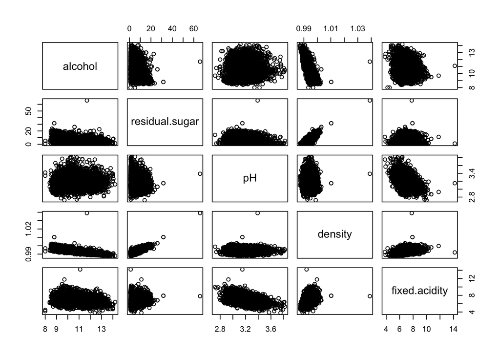

      ```r
      pairs(wines.new)
      ```

      Note that you can also create the plots one-by-one.

      Based on these plots, we can see that some of the variables are linearly correlated with each other and we can also determine the sign of that correlation. For example the alcohol level and density seem to be negatively linearly correlated. If we look at the predictors, then the density and residual sugar seem to show a positive linear relationship, while fixed acidity and pH appear to have a negative linear relationship.
   3. Compute the correlation matrix for all the 5 variables. What are your observations?

      ```r
      cor(wines.new)
      ```

      ```
      ##                   alcohol residual.sugar          pH     density fixed.acidity
      ## alcohol         1.0000000     -0.4506312  0.12143210 -0.78013762    -0.1208811
      ## residual.sugar -0.4506312      1.0000000 -0.19413345  0.83896645     0.0890207
      ## pH              0.1214321     -0.1941335  1.00000000 -0.09359149    -0.4258583
      ## density        -0.7801376      0.8389665 -0.09359149  1.00000000     0.2653310
      ## fixed.acidity  -0.1208811      0.0890207 -0.42585829  0.26533101     1.0000000
      ```

      ```r
      summary(wines.reg)$r.square
      ```

      ```
      ## [1] 0.8541622
      ```

      $R^2$ is approximately 85%, which means that the fitted model is able to explain about 85% of the total variance in the response which represents a high-level reduction in the total variation of alcohol level.
   5. Test whether there is a linear regression relation, using $\alpha=0.05$. State the alternatives, decision rule, and conclusion. What does your test *imply* about $\beta_1$, $\beta_2$, $\beta_3$ and $\beta_4$?

      This is the overall F test:
      $$\begin{cases}
      &H_0: \beta_1 = \beta_2 = \beta_3 = \beta_4 =0\\
      &H_{\alpha}: \beta_j\neq 0 \text{ for some }j
      \end{cases}$$

      We obtain this *overall F test* using the summary of the regression:

      ```r
      summary(wines.reg)
      ```

      ```
      ##
      ## Call:
      ## lm(formula = alcohol ~ residual.sugar + pH + density + fixed.acidity,
      ##     data = wines.new)
      ##
      ## Residuals:
      ##     Min      1Q  Median      3Q     Max
      ## -3.3867 -0.2735 -0.0334  0.2200 16.9366
      ##
      ## Coefficients:
      ##                  Estimate Std. Error t value Pr(>|t|)
      ## (Intercept)     6.790e+02  4.540e+00  149.56   <2e-16 ***
      ## residual.sugar  2.367e-01  2.702e-03   87.58   <2e-16 ***
      ## pH              2.535e+00  5.281e-02   48.01   <2e-16 ***
      ## density        -6.858e+02  4.664e+00 -147.05   <2e-16 ***
      ## fixed.acidity   5.352e-01  9.858e-03   54.30   <2e-16 ***
      ## ---
      ## Signif. codes:  0 '***' 0.001 '**' 0.01 '*' 0.05 '.' 0.1 ' ' 1
      ##
      ## Residual standard error: 0.4702 on 4893 degrees of freedom
      ## Multiple R-squared:  0.8542, Adjusted R-squared:  0.854
      ## F-statistic:  7164 on 4 and 4893 DF,  p-value: < 2.2e-16
      ```

      From the output, we find that the p-value of this F test is much smaller than 2.2*$10^{-16}$, which means that we reject the Null and conclude that there is a statistically significant linear regression relation between tje response the predictors.
   6. Test whether $X_3$ can be dropped from the regression model given that $X_1$, $X_2$ are retained. Use level of significance 0.025. State the alternatives, decision rule and conclusion.

      We test the following hypothesis
      $$\begin{cases}
      &H_0: y_i = \beta_0 + \beta_1 X_{1} + \beta_2 X_2 + \varepsilon_i\\
      &H_{\alpha}: y_i = \beta_0 + \beta_1 X_{1} + \beta_2 X_2 + \beta_3 X_3 + \varepsilon_i
      \end{cases}$$
      using the partial (generalized linear) F test via the `anova` function:

      ```r
      wines.full = lm(alcohol ~ residual.sugar + pH + density, data = wines.new)
      wines.reduced = lm(alcohol ~ residual.sugar + pH, data = wines.new)
      anova(wines.reduced, wines.full)
      ```

      ```
      ## Analysis of Variance Table
      ##
      ## Model 1: alcohol ~ residual.sugar + pH
      ## Model 2: alcohol ~ residual.sugar + pH + density
      ##   Res.Df    RSS Df Sum of Sq     F    Pr(>F)
      ## 1   4895 5901.3
      ## 2   4894 1733.2  1    4168.1 11770 < 2.2e-16 ***
      ## ---
      ## Signif. codes:  0 '***' 0.001 '**' 0.01 '*' 0.05 '.' 0.1 ' ' 1
      ```

      Based on the p-value, we reject the null hypothesis and conclude that the model that contains all three variables is more adequate.
   7. Test whether both $X_2$ and $X_3$ can be dropped from the regression model, given that $X_1$ is retained. Use level of significance 0.025. State the alternatives, decision rule and conclusion.

      We now test the following hypothesis
      $$\begin{cases}
      &H_0: y_i = \beta_0 + \beta_1 X_{1} + \varepsilon_i\\
      &H_{\alpha}: y_i = \beta_0 + \beta_1 X_{1} + \beta_2 X_2 + \beta_3 X_3 + \varepsilon_i
      \end{cases}$$

      ```r
      wines.reduced2 = lm(alcohol ~ residual.sugar, data = wines.new)
      anova(wines.reduced2, wines.full)
      ```

      ```
      ## Analysis of Variance Table
      ##
      ## Model 1: alcohol ~ residual.sugar
      ## Model 2: alcohol ~ residual.sugar + pH + density
      ##   Res.Df    RSS Df Sum of Sq      F    Pr(>F)
      ## 1   4896 5910.2
      ## 2   4894 1733.2  2      4177 5897.4 < 2.2e-16 ***
      ## ---
      ## Signif. codes:  0 '***' 0.001 '**' 0.01 '*' 0.05 '.' 0.1 ' ' 1
      ```

      Again, the p-value is extremely low, so we reject the null hypothesis and conclude that the full model is more adequate compared to the reduced.